# Strings, Dates, and Factors

Lecture 05a  
POLS 6394 · Tuesday, September 22

## Today

- Search and standardize text before grouping or joining.
- Parse dates and check the results.
- Recode category values and choose a useful order.
- Lab: prepare hearing records for a summary.

## Why these columns matter

Real datasets often arrive with inconsistent names, dates stored as text, and category codes that need explanation. These details affect the answers we get.

- **Strings:** `"Judiciary"` and `"JUDICIARY"` count as different committees until we standardize them.
- **Dates:** R needs to recognize dates to select a period or calculate days between events.
- **Categories:** readable labels and a sensible order make tables and plots easier to interpret.

We’ll use these tools to prepare hearing records for analysis and next class’s plots.

## Setup

Run this chunk as written. The tidyverse loads `stringr`, `lubridate`, and `forcats`. We also load janitor for cleaning helpers. The hearings file is a small teaching example with one row per hearing; `hearing_id` identifies the row and `witnesses` counts witnesses.

```r
library(tidyverse)
library(janitor)
hearings <- read_csv("Labs/w04/hearings_messy.csv",
                     show_col_types = FALSE)
```

# Cleaning records

## Inspect duplicate identifiers

A repeated ID can inflate counts or multiply rows in a join. Janitor’s `get_dupes()` shows all records sharing the columns we specify, plus a `dupe_count` column.

```r
registrations <- tibble(
  person_id = c(101, 102, 102),
  district = c("North", "South", "West")
)
registrations |> get_dupes(person_id)
```

```
# A tibble: 2 × 3
  person_id dupe_count district
      <dbl>      <int> <chr>
1       102          2 South
2       102          2 West
```

Person 102 has conflicting districts. Investigate before deleting either row. For data with one row per person per year, check both columns: `get_dupes(person_id, year)`.

## Remove entirely empty rows and columns

Spreadsheets sometimes contain unused rows or columns. Janitor’s `remove_empty()` removes those containing only `NA`, while keeping partially observed records.

```r
sheet <- tibble(
  district = c("North", NA, "South"),
  turnout = c(62, NA, NA),
  unused = c(NA, NA, NA)
)
sheet_clean <- sheet |> remove_empty(c("rows", "cols"))
sheet_clean
```

```
# A tibble: 2 × 2
  district turnout
  <chr>      <dbl>
1 North         62
2 South         NA
```

`"rows"` and `"cols"` select what to remove. South stays, despite its missing turnout. Empty strings (`""`) aren’t `NA`.

## Empty rows versus incomplete records

Compare the cleaned sheet with the result of `drop_na()`. With no column specified, `drop_na()` removes a row if **any** value is missing.

```r
sheet_clean |> drop_na()
```

```
# A tibble: 1 × 2
  district turnout
  <chr>      <dbl>
1 North         62
```

Only North remains. Use `remove_empty()` for unused spreadsheet space. Decide which missing values justify excluding observations separately.

# Strings

## Inspect text before changing it

These example meeting topics differ in case and spacing. `str_detect()` returns one Boolean value per string.

```r
topics <- tibble(topic = c("Housing", "HOUSING AND TRANSIT",
                           "Transit", "  Housing  "))
topics |>
  mutate(matches = str_detect(topic, "Housing"))
```

```
# A tibble: 4 × 2
  topic                 matches
  <chr>                 <lgl>
1 "Housing"             TRUE
2 "HOUSING AND TRANSIT" FALSE
3 "Transit"             FALSE
4 "  Housing  "         TRUE
```

Matching is case-sensitive: `"Housing"` misses `"HOUSING"`.

## Match regardless of case

Wrap the search text in `regex()` with `ignore_case = TRUE` to match either capitalization.

```r
topics |>
  filter(str_detect(topic, regex("housing", ignore_case = TRUE)))
```

```
# A tibble: 3 × 1
  topic
  <chr>
1 "Housing"
2 "HOUSING AND TRANSIT"
3 "  Housing  "
```

A regular expression describes a text pattern. Plain words work too. This search matches text anywhere in the value.

Detection identifies records to inspect before we change them. In the lab, we’ll create cleaned columns and compare them with the originals.

## Turn matches into a category

Text detection can feed a coding rule. This example uses `case_when()` to classify descriptions. The first matching condition wins, so the more specific combined category comes first.

```r
tibble(description = c("Housing hearing", "Transit hearing",
                       "Housing and transit hearing", "Budget hearing")) |>
  mutate(topic_group = case_when(
    str_detect(description, regex("housing", ignore_case = TRUE)) &
      str_detect(description, regex("transit", ignore_case = TRUE)) ~
      "Housing and transit",
    str_detect(description, regex("housing", ignore_case = TRUE)) ~ "Housing",
    str_detect(description, regex("transit", ignore_case = TRUE)) ~ "Transit",
    .default = "Other"
  ))
```

```
# A tibble: 4 × 2
  description                 topic_group
  <chr>                       <chr>
1 Housing hearing             Housing
2 Transit hearing             Transit
3 Housing and transit hearing Housing and transit
4 Budget hearing              Other
```

This is a small text-coding scheme. Its categories and ordering are research decisions that should be documented.

## Why use a regular expression?

A regular expression describes a text pattern. It helps when we want every value with the same structure rather than a list of exact names. Here we want IDs that start with `"TX-"`, not IDs that mention TX somewhere else.

Run this supplied example. `^` means the beginning of the string; you don’t need to write a pattern yourself today.

```r
tibble(id = c("TX-101", "CA-TX-102", "TX-103")) |>
  mutate(anywhere = str_detect(id, "TX"),
         at_start = str_detect(id, "^TX-"))
```

```
# A tibble: 3 × 3
  id        anywhere at_start
  <chr>     <lgl>    <lgl>
1 TX-101    TRUE     TRUE
2 CA-TX-102 TRUE     FALSE
3 TX-103    TRUE     TRUE
```

## Choose the capitalization you need

Lowercase can help standardize a matching key; uppercase can preserve abbreviations. Title case is useful for some display labels, but it would turn `"NASA"` into `"Nasa"`.

```r
tibble(raw = c("city council", "NASA")) |>
  mutate(lower = str_to_lower(raw),
         upper = str_to_upper(raw),
         title = str_to_title(raw))
```

```
# A tibble: 2 × 4
  raw          lower        upper        title
  <chr>        <chr>        <chr>        <chr>
1 city council city council CITY COUNCIL City Council
2 NASA         nasa         NASA         Nasa
```

## Clean spacing and capitalization

Keep the original column so we can see what changed. The inner function runs first: `str_squish()` removes outer spaces and collapses repeated internal spaces; `str_to_title()` changes capitalization.

```r
tibble(raw = c("CITY COUNCIL", "City  Council", "city council")) |>
  mutate(clean = str_to_title(str_squish(raw)))
```

```
# A tibble: 3 × 2
  raw           clean
  <chr>         <chr>
1 CITY COUNCIL  City Council
2 City  Council City Council
3 city council  City Council
```

Standardize known equivalent labels before counting or joining. Inspect names and acronyms before changing their capitalization.

## Cleaning changes the counts

Before cleaning, spelling differences create separate groups. Count the raw and cleaned values side by side to see what the transformation actually did.

```r
committee_names <- tibble(
  committee_raw = c("JUDICIARY", "Judiciary", " judiciary ",
                    "Agriculture")
)
committee_names_clean <- committee_names |>
  mutate(committee_clean = str_to_title(str_squish(committee_raw)))
committee_names |> count(committee_raw)
```

```
# A tibble: 4 × 2
  committee_raw     n
  <chr>         <int>
1 " judiciary "     1
2 "Agriculture"     1
3 "JUDICIARY"       1
4 "Judiciary"       1
```

```r
committee_names_clean |> count(committee_clean)
```

```
# A tibble: 2 × 2
  committee_clean     n
  <chr>           <int>
1 Agriculture         1
2 Judiciary           3
```

The three Judiciary spellings now share one cleaned label. Keeping both columns makes that consolidation visible and checkable.

## Replace text inside a value

Use `str_replace()` to change the first occurrence, or `str_replace_all()` to change every occurrence. The arguments give the original text, the text to find, and its replacement.

```r
tibble(raw = "Public_Health_Committee") |>
  mutate(first = str_replace(raw, "_", " "),
         every = str_replace_all(raw, "_", " "))
```

```
# A tibble: 1 × 3
  raw                     first                   every
  <chr>                   <chr>                   <chr>
1 Public_Health_Committee Public Health_Committee Public Health Committee
```

This changes text inside a value. Later we’ll recode whole values, such as a party code into a full party name.

## Extract part of an identifier

A county FIPS identifier has five digits: two for the state and three for the county within that state. These are labels, not quantities to add or average. Keep them as character columns.

`str_sub(text, start, end)` extracts characters by position, counting from 1 and including both endpoints.

```r
tibble(county_id = c("01001", "06037", "48201")) |>
  mutate(state_id = str_sub(county_id, 1, 2),
         county_part = str_sub(county_id, 3, 5))
```

```
# A tibble: 3 × 3
  county_id state_id county_part
  <chr>     <chr>    <chr>
1 01001     01       001
2 06037     06       037
3 48201     48       201
```

## Restore a known leading zero

Suppose those identifiers were imported as numbers. `as.character()` converts them to text; `str_pad()` adds zeros on the left until each value has five characters.

```r
tibble(imported_id = c(1001, 6037, 48201)) |>
  mutate(county_id = str_pad(as.character(imported_id),
                            width = 5, side = "left", pad = "0"))
```

```
# A tibble: 3 × 2
  imported_id county_id
        <dbl> <chr>
1        1001 01001
2        6037 06037
3       48201 48201
```

Use five only because the source specifies five-digit county IDs. Padding cannot tell us the correct width or whether a code is valid.

## Recode category values

`rename()` changes column names; `recode()` changes values inside a column. Use it inside `mutate()` to create readable labels while keeping the original codes.

```r
party_codes <- tibble(party_code = c("D", "R", "I", "Other"))
party_codes |>
  mutate(party_label = recode(party_code,
                             "D" = "Democrat",
                             "R" = "Republican",
                             "I" = "Independent"))
```

```
# A tibble: 4 × 2
  party_code party_label
  <chr>      <chr>
1 D          Democrat
2 R          Republican
3 I          Independent
4 Other      Other
```

Each named pair gives an old value and its replacement. With character replacements, an unlisted character value such as `"Other"` stays unchanged.

## Your Turn: recode another column

*~3 minutes.*

Create `response_label`: Y becomes Yes, N becomes No, and DK becomes Don’t know. Leave Refused unlisted. Check that the original codes remain and Refused is unchanged.

```r
# Fill in, then delete the eval:false line and re-render.
response_codes <- tibble(response_code = c("Y", "N", "DK", "Refused"))
response_codes |>
  mutate(response_label = recode(___,
                                "Y" = "Yes",
                                ___ = "No",
                                "DK" = ___))
```

## Mark a documented code as missing

Some files use text for missing data. If the documentation identifies `"Not reported"` as a missing code, `na_if(x, y)` replaces exact matches to `y` with `NA`.

```r
tibble(status_raw = c("Complete", "Not reported", "Partial")) |>
  mutate(status = na_if(status_raw, "Not reported"))
```

```
# A tibble: 3 × 2
  status_raw   status
  <chr>        <chr>
1 Complete     Complete
2 Not reported <NA>
3 Partial      Partial
```

Keep the raw column for checking. Don’t convert a meaningful response such as `"None"` to missing just because it sounds similar.

# Dates

## Choose the order of date parts

The parser name tells R how to read the parts: year–month–day, month–day–year, or day–month–year. Different separators can use the same parser.

```r
ymd(c("2021-03-04", "2021/03/04"))
```

```
[1] "2021-03-04" "2021-03-04"
```

```r
mdy(c("03/15/2021", "April 2, 2021"))
```

```
[1] "2021-03-15" "2021-04-02"
```

```r
dmy("15/03/2021")
```

```
[1] "2021-03-15"
```

These functions return `Date` values, which R can compare and subtract. A value such as `03/04/2021` is ambiguous. When you control the format, use the ISO 8601 year–month–day form—`2021-03-04`—which is unambiguous and also sorts chronologically as text.

## Build dates from separate columns

Some files store year, month, and day in separate columns. Lubridate’s `make_date()` combines them without first constructing text.

```r
tibble(year = c(2020, 2021),
       month = c(11, 1),
       day = c(3, 20)) |>
  mutate(election_date = make_date(year, month, day))
```

```
# A tibble: 2 × 4
   year month   day election_date
  <dbl> <dbl> <dbl> <date>
1  2020    11     3 2020-11-03
2  2021     1    20 2021-01-20
```

This is safer than pasting the three values together and guessing how the resulting string will be parsed.

## Parse mixed formats

When a column mixes known orders, `parse_date_time()` can try several. `orders` supplies the allowed orders; this example has year-first and month-first dates.

```r
date_examples <- tibble(raw = c("2021-03-04", "April 2, 2021",
                                "2022/01/19"))
parsed_examples <- date_examples |>
  mutate(date = as_date(parse_date_time(raw,
                                       orders = c("ymd", "mdy"))))
parsed_examples
```

```
# A tibble: 3 × 2
  raw           date
  <chr>         <date>
1 2021-03-04    2021-03-04
2 April 2, 2021 2021-04-02
3 2022/01/19    2022-01-19
```

The parser returns a date-time. Lubridate’s `as_date()` keeps the calendar date. Don’t add `"dmy"` unless the source actually uses it.

## When Excel dates arrive as numbers

Excel can store dates as a count of days. If a date column imports as numbers such as 42370, `ymd()` won’t interpret that encoding correctly. Janitor’s `excel_numeric_to_date()` converts those serial numbers.

```r
tibble(excel_date = c(42370, 42371)) |>
  mutate(date = excel_numeric_to_date(excel_date))
```

```
# A tibble: 2 × 2
  excel_date date
       <dbl> <date>
1      42370 2016-01-01
2      42371 2016-01-02
```

In Excel’s standard system, serial number 1 represents January 1, 1900, and each later integer advances one day. These values become January 1 and 2, 2016. Excel also preserves a historical 1900 leap-year error, which the janitor helper handles. Verify a known date before converting a column.

## Check conversions

Count failed conversions and inspect those rows before continuing. A parser can return `NA` for invalid or unrecognized dates.

```r
parsed_examples |>
  summarize(failed = sum(is.na(date)))
```

```
# A tibble: 1 × 1
  failed
   <int>
1      0
```

```r
parsed_examples |>
  filter(is.na(date))
```

```
# A tibble: 0 × 2
# ℹ 2 variables: raw <chr>, date <date>
```

Here the count should be zero and the second result should have no rows. These checks assume the raw example dates are all present.

## A successful parse can still be wrong

A wrong date order can produce a valid but incorrect date. After counting failures, inspect the range and a few raw–parsed pairs.

```r
parsed_examples |>
  summarize(first_date = min(date, na.rm = TRUE),
            last_date = max(date, na.rm = TRUE))
```

```
# A tibble: 1 × 2
  first_date last_date
  <date>     <date>
1 2021-03-04 2022-01-19
```

```r
parsed_examples |>
  select(raw, date)
```

```
# A tibble: 3 × 2
  raw           date
  <chr>         <date>
1 2021-03-04    2021-03-04
2 April 2, 2021 2021-04-02
3 2022/01/19    2022-01-19
```

Compare these results with the source’s time period and documentation. Zero missing values is only one part of validation.

## Filter and sort dates

Once values are dates, we can select a period and put its events in chronological order. `>=` and `<=` include the endpoints; the comma in `filter()` requires both conditions.

```r
parsed_examples |>
  filter(date >= ymd("2021-01-01"),
         date <= ymd("2021-12-31")) |>
  arrange(date)
```

```
# A tibble: 2 × 2
  raw           date
  <chr>         <date>
1 2021-03-04    2021-03-04
2 April 2, 2021 2021-04-02
```

This keeps March 4 and April 2, 2021 and excludes January 19, 2022. Sorting the original text instead would depend on its spelling and format.

## Extract parts and calculate elapsed days

`year()` extracts the year. `month(label = TRUE)` creates month labels in calendar order. Subtracting `Date` values accounts for month lengths and leap years; `as.integer()` displays the elapsed days. Calendar months and years don’t have fixed numbers of days.

```r
parsed_examples |>
  mutate(year = year(date),
         month = month(date, label = TRUE),
         elapsed_days = as.integer(date - ymd("2021-01-01")))
```

```
# A tibble: 3 × 5
  raw           date        year month elapsed_days
  <chr>         <date>     <dbl> <ord>        <int>
1 2021-03-04    2021-03-04  2021 Mar             62
2 April 2, 2021 2021-04-02  2021 Apr             91
3 2022/01/19    2022-01-19  2022 Jan            383
```

Keep the year when summarizing several years. Grouping on month alone pools all Januaries, all Februaries, and so on.

# Factors

## Characters and factors

Character columns store text. A factor stores categories with a defined set of levels. Inspect the levels to see their display order.

```r
priority <- c("Medium", "High", "Low", "Medium")
priority
```

```
[1] "Medium" "High"   "Low"    "Medium"
```

```r
priority_factor <- factor(priority)
levels(priority_factor)
```

```
[1] "High"   "Low"    "Medium"
```

`factor()` defaults to sorted levels. A level sequence alone does not declare an ordered factor or a substantive ranking.

## Set a useful order

For priority, alphabetical order is unhelpful. `fct_relevel()` puts the named levels first in the order we supply.

```r
priority_factor <- fct_relevel(priority_factor, "Low", "Medium", "High")
levels(priority_factor)
```

```
[1] "Low"    "Medium" "High"
```

```r
tibble(priority = priority_factor) |>
  count(priority)
```

```
# A tibble: 3 × 2
  priority     n
  <fct>    <int>
1 Low          1
2 Medium       2
3 High         1
```

Changing levels changes display order without changing anyone’s recorded category.

## Order categories by a measurement

Sometimes the data should determine the order. `fct_reorder(category, value)` orders levels by the median value in each category, ascending by default.

```r
requests <- tibble(service = c("Housing", "Transit", "Water"),
                   requests = c(12, 30, 8))
requests_ordered <- requests |>
  mutate(service = fct_reorder(service, requests))
levels(requests_ordered$service)
```

```
[1] "Water"   "Housing" "Transit"
```

Here each service has one row. `$` extracts the column so we can inspect its levels.

## Order categories by frequency

When the question is simply which category appears most often, `fct_infreq()` orders levels from most to least frequent.

```r
service_calls <- tibble(
  service = c("Housing", "Transit", "Transit", "Water",
              "Transit", "Housing")
)
service_calls |>
  mutate(service = fct_infreq(service)) |>
  count(service)
```

```
# A tibble: 3 × 2
  service     n
  <fct>   <int>
1 Transit     3
2 Housing     2
3 Water       1
```

Use `fct_relevel()` for a substantive order such as Low–Medium–High, `fct_reorder()` for another measured value, and `fct_infreq()` for frequency.

## Preview: the order appears in the chart

The first plot uses the original alphabetical order. The second uses the order stored in the corrected factor. We’ll teach the plotting syntax Thursday.

**Original: alphabetical**

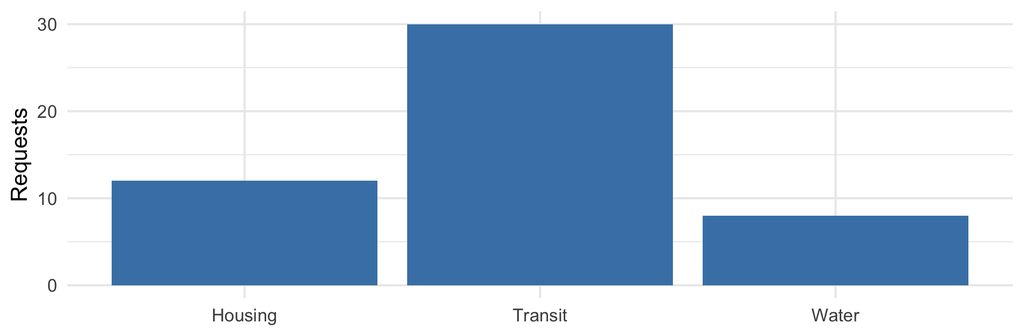

**Corrected: ordered by requests**

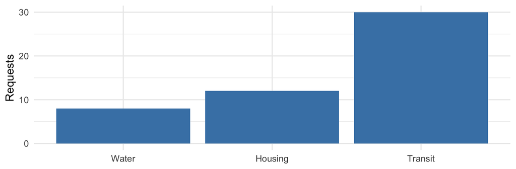

## Your Turn: order ideology

*~3 minutes.*

R’s alphabetical order puts Conservative first. Reorder the levels to Liberal, Moderate, Conservative, then inspect the result.

```r
# Fill in, then delete the eval:false line and re-render.
ideology <- factor(c("Moderate", "Conservative", "Liberal", "Moderate"))
levels(ideology)
ideology <- fct_relevel(ideology, ___)
levels(ideology)
```

The values do not change; only their level order changes.

# Lab

## Lab: prepare hearing records

*~10 minutes in class; finish the remaining tasks at home.*

Start with Task 1 and continue in order. Amanda and I will circulate while you work. After about ten minutes, we’ll stop and save your progress.

The workbook has four tasks:

1. Inspect the original dates and committee spellings.
2. Parse the dates and check for failed conversions.
3. Standardize committee names, keeping the originals.
4. Count hearings by year, month, and committee.

You should have 15 parsed dates, four committees, and counts that sum to 15. Use the supplied plot to inspect the summary.

## Finalize 05a

- After the ten-minute lab block, save and render your progress. Keep unfinished chunks at `eval: false`.
- Inspect changes, commit, and push before leaving. This commit records your in-class work. The lab does not need to be finished yet.
- Confirm the commit appears on GitHub. If rendering fails, record the error and push the saved QMD.
- Finish the remaining tasks at home, then render again, commit, and push.

## Before Next Class

- Thursday, September 24: ggplot2, from data and mappings to plots.
- Read Healy, *Data Visualization*, chapters 3–4 before Thursday.

# If Time Remains

## Additional teaching and practice

These are optional worked examples for us to go through together, with explanations of the results. They are not extra-credit assignments.

## Extension 1a: choose a priority

*~8–10 minutes for this activity.*

Suppose a report requires one category per meeting. These two rules differ only in which match comes first.

```r
topics |>
  transmute(
    topic,
    housing_first = case_when(
      str_detect(topic, regex("housing", ignore_case = TRUE)) ~ "Housing",
      str_detect(topic, regex("transit", ignore_case = TRUE)) ~ "Transit",
      .default = "Other"),
    transit_first = case_when(
      str_detect(topic, regex("transit", ignore_case = TRUE)) ~ "Transit",
      str_detect(topic, regex("housing", ignore_case = TRUE)) ~ "Housing",
      .default = "Other")
  )
```

```
# A tibble: 4 × 3
  topic                 housing_first transit_first
  <chr>                 <chr>         <chr>
1 "Housing"             Housing       Housing
2 "HOUSING AND TRANSIT" Housing       Transit
3 "Transit"             Transit       Transit
4 "  Housing  "         Housing       Housing
```

`case_when()` uses the first match, so the combined topic changes categories. A one-category scheme requires a documented priority rule. Next we’ll allow both topics instead. **Answer on the next slide.**

## Extension 1b: allow both topics

Separate Boolean columns preserve overlapping classifications. A meeting may count toward both topics because these columns answer two independent yes-or-no questions.

```r
topic_flags <- topics |>
  mutate(housing = str_detect(topic, regex("housing", ignore_case = TRUE)),
         transit = str_detect(topic, regex("transit", ignore_case = TRUE)))
topic_flags
```

```
# A tibble: 4 × 3
  topic                 housing transit
  <chr>                 <lgl>   <lgl>
1 "Housing"             TRUE    FALSE
2 "HOUSING AND TRANSIT" TRUE    TRUE
3 "Transit"             FALSE   TRUE
4 "  Housing  "         TRUE    FALSE
```

```r
topic_flags |> summarize(housing = sum(housing), transit = sum(transit))
```

```
# A tibble: 1 × 2
  housing transit
    <int>   <int>
1       3       2
```

The choice depends on the research question: a mutually exclusive typology needs a documented priority, while topic prevalence often calls for separate indicators.

## Extension 2a: inspect rare categories

*~8–10 minutes for this activity.*

This supplied setup works independently of the lab. Inspect the counts before combining categories.

```r
committee_rows <- hearings |>
  mutate(committee = str_to_title(str_squish(committee)))
committee_rows |> count(committee, sort = TRUE)
```

```
# A tibble: 4 × 2
  committee             n
  <chr>             <int>
1 Judiciary             5
2 Armed Services        4
3 Finance               3
4 Foreign Relations     3
```

The counts are 5, 4, 3, and 3. Keeping the three most common categories with `fct_lump_n(n = 3)` would retain both tied categories and keep all four.

## Extension 2b: choose a threshold

`fct_lump_min(category, min = 4)` keeps categories with at least four rows and combines the rest into `"Other"`. Use a new column to preserve the original labels.

```r
committee_rows |>
  mutate(display_group = fct_lump_min(committee, min = 4)) |>
  count(display_group, sort = TRUE)
```

```
# A tibble: 3 × 2
  display_group      n
  <fct>          <int>
1 Other              6
2 Judiciary          5
3 Armed Services     4
```

Next we’ll raise the threshold to 5 and check which committees move into Other. **Answer on the next slide.**

## Extension 2c: what Other contains

At `min = 4`, Finance and Foreign Relations each have 3 hearings, so Other has 6. Judiciary (5) and Armed Services (4) stay separate.

```r
committee_rows |>
  mutate(display_group = fct_lump_min(committee, min = 5)) |>
  count(display_group, sort = TRUE)
```

```
# A tibble: 2 × 2
  display_group     n
  <fct>         <int>
1 Other            10
2 Judiciary         5
```

At `min = 5`, Armed Services also moves into Other: Judiciary has 5 and Other has 10. The total stays 15, but the display no longer distinguishes three committees. Choose the threshold based on what readers need to compare.